# Is OwenQ reliable?

Stéphane Laurent

2023-04-11

# 1 Purpose

The purpose of this vignette is to assess the correctness of the functions of the `OwenQ` package.

As said in the main vignette, the fourth Owen cumulative function $O_4$, implemented under the name `powen4` allows to evaluate the power of equivalence tests. This is perhaps the main application of the `OwenQ` package and we will particularly focus on this situation.

Our strategy runs as follows:

- To test the `OwenT` function, we will compare some values it returns to those returned by other implementations. Note that the other functions of the `OwenQ` package rely on `OwenT` when the number of degrees of freedom is odd. Therefore, by testing these other functions for an odd number of degrees of freedom, we implicitely test the `OwenT` function.
- We will compare a couple of values returned by `OwenQ1` and `OwenQ2` to the values obtained by numerical integration in Wolfram|Alpha.
- We will test `powen4` by performing some power calculations relying on this function and comparing the results with the ones provided by SAS. We will also perform these power calculations with the help of the `ipowen4` function, which evaluates the $O_4$ function by a powerful numerical integration, and we will compare the results.
- These power calculations will be performed for $100$ different scenarios, and we will conclude that `powen4` is reliable for these scenarios. Then, to test the other functions of the `OwenQ` package, we will check that some mathematical relations hold for these $100$ scenarios.

The folder `tests/testthat` of the `OwenQ` package contains many comparisons with Wolfram|Alpha. The results we obtain with `OwenQ` are always the same as the ones obtained with Wolfram|Alpha up to a tolerance of at least $10$ decimal digits.

# 2 Owen $T$-function (`OwenT`)

The Owen $T$-function is implemented under the name `OwenT`. This is a port of the function `owens_t` of the C++ `special_functions` library included in the `boost` set of libraries. Some details about the C++ implementation are [available here](https://www.boost.org/doc/libs/1_77_0/libs/math/doc/html/math_toolkit/owens_t.html).

The libraries provided by `boost` are peer-reviewed, and this is enough to trust the reliability of `OwenT`. Nevertheless, below we compare the results of `OwenT` to the six values given in Patefield’s article, up to $14$ decimal digits. We have also checked that Wolfram|Alpha gives these values.

```r
testData <- data.frame(
  h = c(0.0625, 6.5, 7, 4.78125, 2, 1),
  a = c(0.25, 0.4375, 0.96875, 0.0625, 0.5, 0.9999975),
  Patefield = c(3.8911930234701e-02, 2.0005773048508e-11, 6.3990627193899e-13, 1.0632974804687e-07, 8.6250779855215e-03, 6.6741808978229e-02),
  OwenT = numeric(6)
)
for(i in 1:nrow(testData)){
  testData$OwenT[i] <- OwenT(testData$h[i], testData$a[i])
}
print(testData, digits=14)
```

```
##         h         a           Patefield               OwenT
## 1 0.06250 0.2500000 3.8911930234701e-02 3.8911930234701e-02
## 2 6.50000 0.4375000 2.0005773048508e-11 2.0005773048508e-11
## 3 7.00000 0.9687500 6.3990627193899e-13 6.3990627193899e-13
## 4 4.78125 0.0625000 1.0632974804687e-07 1.0632974804687e-07
## 5 2.00000 0.5000000 8.6250779855215e-03 8.6250779855215e-03
## 6 1.00000 0.9999975 6.6741808978229e-02 6.6741808978229e-02
```

We get the same results with `OwenT`.

# 3 Owen $Q$-functions: comparing a couple of values

The two Owen $Q$-functions $Q_1$ and $Q_2$ are defined by:
$$Q_1(\nu, t, \delta, R) =
\frac{1}{\Gamma\left(\frac{\nu}{2}\right)2^{\frac12(\nu-2)}}
\int_0^R \Phi\left(\frac{tx}{\sqrt{\nu}}-\delta\right)
x^{\nu-1} e^{-\frac{x^2}{2}} \mathrm{d}x$$
and
$$Q_2(\nu, t, \delta, R) =
\frac{1}{\Gamma\left(\frac{\nu}{2}\right)2^{\frac12(\nu-2)}}
\int_R^\infty \Phi\left(\frac{tx}{\sqrt{\nu}}-\delta\right)
x^{\nu-1} e^{-\frac{x^2}{2}} \mathrm{d}x.$$

They are implemented in the `OwenQ` package under the respective names `OwenQ1` and `OwenQ2`, for integer values of $\nu$, following Owen’s algorithm (1965).

In Wolfram|Alpha, these functions are not available, but we can evaluate them by numerical integration.

Below we compare two values of `OwenQ1` to the ones returned by Wolfram|Alpha.

- $\nu=3$, $t=3$, $\delta=2$, $R=5$ (link to Wolfram)

```r
# wolfram: Integrate[(1+Erf[(3*x/Sqrt[3]-2)/Sqrt[2]])*x^(3-1)*Exp[-x^2/2],{x,0,5}]/2/Gamma[3/2]/2^((3-2)/2)
OwenQ1(3, 3, 2, 5)
```

```
## [1] 0.6800117
```

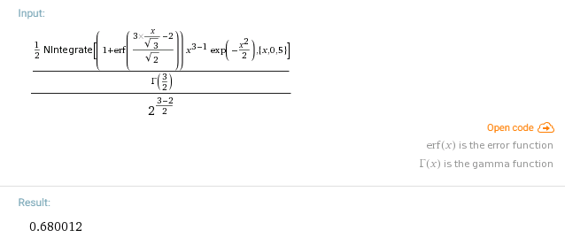

Our value rounded to $6$ digits is the same as the one given by Wolfram.

- $\nu=1000$, $t=3$, $\delta=2$, $R=30$ (link to Wolfram)

```r
# wolfram: Integrate[(1+Erf[(3*x/Sqrt[1000]-2)/Sqrt[2]])*x^(1000-1)*Exp[-x^2/2],{x,0,30}]/2/Gamma[1000/2]/2^((1000-2)/2)
print(OwenQ1(1000, 3, 2, 30), digits=16)
```

```
## [1] 0.008518809463589428
```

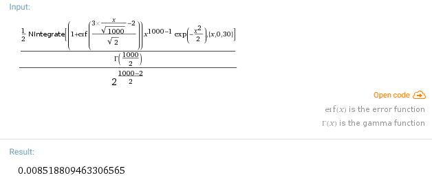

Now we compare two values of `OwenQ2` to the ones returned by Wolfram|Alpha.

- $\nu=3$, $t=3$, $\delta=2$, $R=5$ (link to Wolfram)

```r
# wolfram: Integrate[(1+Erf[(3*x/Sqrt[3]-2)/Sqrt[2]])*x^(3-1)*Exp[-x^2/2],{x,5,Infinity}]/2/Gamma[3/2]/2^((3-2)/2)
OwenQ2(3, 3, 2, 5)
```

```
## [1] 1.54405e-05
```

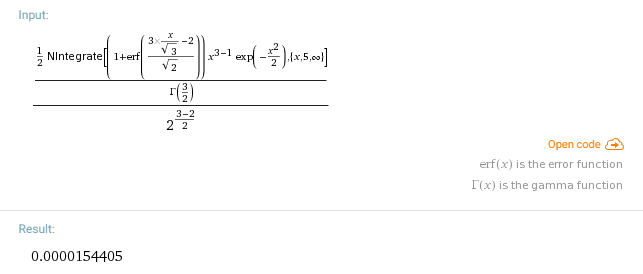

The two values are identical.

- $\nu=1000$, $t=3$, $\delta=2$, $R=5$ (link To Wolfram)

```r
# wolfram: Integrate[(1+Erf[(3*x/Sqrt[1000]-2)/Sqrt[2]])*x^(1000-1)*Exp[-x^2/2],{x,5,Infinity}]/2/Gamma[1000/2]/2^((1000-2)/2)
print(OwenQ2(1000, 3, 2, 5), digits=16)
```

```
## [1] 0.8406201459600969
```

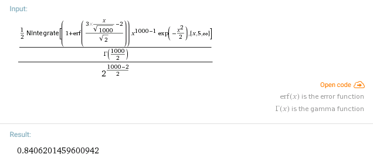

The two values are identical up to $13$ digits.

# 4 Fourth Owen cumulative function $O_4$ (`powen4`)

As seen in the other vignette, the fourth Owen cumulative function $O_4$, implemented under the name `powen4`, can be used to evaluate the power of equivalence tests.

The `powerTOST` function below returns the power of the equivalence test for a so-called parallel design with equal variances, when considering the alternative hypothesis $H_1\colon\{-\Delta < \delta_0 < \Delta \}$, where $\delta_0$ denotes the difference between the two means. This function takes as arguments the significance level $\alpha$, the difference $\delta_0$ between the two means, the threshold $\Delta$, the common standard deviation $\sigma$ of the two samples, and the two sample sizes $n_1$ and $n_2$.

```r
powerTOST <- function(alpha, delta0, Delta, sigma, n1, n2, algo=2) {
  se <- sqrt(1/n1 + 1/n2) * sigma
  delta1 <- (delta0 + Delta) / se
  delta2 <- (delta0 - Delta) / se
  dof <- n1 + n2 - 2
  q <- qt(1 - alpha, dof)
  powen4(dof, q, -q, delta1, delta2, algo=algo)
}
```

As you can see, the `powen4` function has an argument `algo`. This is also the case for the other Owen functions, except for `ptOwen`. The `algo` argument can take two values, `1` or `2`. Th default value is `algo=2`, and as we will see later, the evaluation is more reliable with this option. The value of `algo` corresponds to a small difference in the algorithm. With `algo=1`, the evaluation is a bit faster. And we will see that `powerTOST`  
is reliable for `algo=1` when the value of `n1+n2` is not too large.

## 4.1 Comparisons with SAS

The table shown below contains $100$ results of power calculations with SAS version 9.4, for a total sample size $n_1+n_2$ going from $20$ to $1200$. The results are rounded to $5$ decimal digits.

|  | alpha | delta0 | Delta | sigma | n1 | n2 | powerSAS |
| --- | --- | --- | --- | --- | --- | --- | --- |
| 1 | 0.05 | 0.0 | 1 | 1 | 10 | 10 | 0.39094 |
| 2 | 0.05 | 0.0 | 1 | 1 | 15 | 15 | 0.69541 |
| 3 | 0.05 | 0.0 | 1 | 1 | 20 | 20 | 0.85580 |
| 4 | 0.05 | 0.0 | 1 | 1 | 25 | 25 | 0.93426 |
| 5 | 0.05 | 0.0 | 1 | 1 | 30 | 30 | 0.97092 |
| 6 | 0.05 | 0.1 | 1 | 1 | 10 | 10 | 0.38272 |
| 7 | 0.05 | 0.1 | 1 | 1 | 15 | 15 | 0.67836 |
| 8 | 0.05 | 0.1 | 1 | 1 | 20 | 20 | 0.83661 |
| 9 | 0.05 | 0.1 | 1 | 1 | 25 | 25 | 0.91781 |
| 10 | 0.05 | 0.1 | 1 | 1 | 30 | 30 | 0.95889 |
| 11 | 0.05 | 0.2 | 1 | 1 | 10 | 10 | 0.35908 |
| 12 | 0.05 | 0.2 | 1 | 1 | 15 | 15 | 0.62954 |
| 13 | 0.05 | 0.2 | 1 | 1 | 20 | 20 | 0.78069 |
| 14 | 0.05 | 0.2 | 1 | 1 | 25 | 25 | 0.86796 |
| 15 | 0.05 | 0.2 | 1 | 1 | 30 | 30 | 0.92017 |
| 16 | 0.05 | 0.3 | 1 | 1 | 10 | 10 | 0.32287 |
| 17 | 0.05 | 0.3 | 1 | 1 | 15 | 15 | 0.55540 |
| 18 | 0.05 | 0.3 | 1 | 1 | 20 | 20 | 0.69322 |
| 19 | 0.05 | 0.3 | 1 | 1 | 25 | 25 | 0.78471 |
| 20 | 0.05 | 0.3 | 1 | 1 | 30 | 30 | 0.84909 |
| 21 | 0.05 | 0.4 | 1 | 1 | 10 | 10 | 0.27820 |
| 22 | 0.05 | 0.4 | 1 | 1 | 15 | 15 | 0.46531 |
| 23 | 0.05 | 0.4 | 1 | 1 | 20 | 20 | 0.58306 |
| 24 | 0.05 | 0.4 | 1 | 1 | 25 | 25 | 0.67174 |
| 25 | 0.05 | 0.4 | 1 | 1 | 30 | 30 | 0.74260 |
| 26 | 0.05 | 0.5 | 1 | 1 | 10 | 10 | 0.22970 |
| 27 | 0.05 | 0.5 | 1 | 1 | 15 | 15 | 0.36967 |
| 28 | 0.05 | 0.5 | 1 | 1 | 20 | 20 | 0.46208 |
| 29 | 0.05 | 0.5 | 1 | 1 | 25 | 25 | 0.53883 |
| 30 | 0.05 | 0.5 | 1 | 1 | 30 | 30 | 0.60600 |

[output cut: 70 more lines]

This table is stored in a dataframe named `SAS`. We compare the SAS values to the ones obtained by our `powerTOST` function.

```r
power <- numeric(nrow(SAS))
for (i in 1:nrow(SAS)) {
  power[i] <-
    powerTOST(
      alpha = SAS$alpha[i],
      delta0 = SAS$delta0[i],
      Delta = SAS$Delta[i],
      sigma = SAS$sigma[i],
      n1 = SAS$n1[i],
      n2 = SAS$n2[i]
    )
}
```

Rounding our values to $5$ decimal digits, we find that our results are identical to the SAS results:

```r
identical(round(power,5), SAS$powerSAS)
```

```
## [1] TRUE
```

With the option `algo=1`, the results are identical as well:

```r
power <- numeric(nrow(SAS))
for (i in 1:nrow(SAS)) {
  power[i] <-
    powerTOST(
      alpha = SAS$alpha[i],
      delta0 = SAS$delta0[i],
      Delta = SAS$Delta[i],
      sigma = SAS$sigma[i],
      n1 = SAS$n1[i],
      n2 = SAS$n2[i],
      algo = 1
    )
}
identical(round(power,5), SAS$powerSAS)
```

```
## [1] TRUE
```

## 4.2 Comparison with numerical integration

The `ipowen4` internal function of the `OwenQ` package evaluates the fourth Owen cumulative function $O_4$ by a powerful numerical integration implemented in C++ (with the package `RcppNumerical`). Thus we have two completely different implementations of $O_4$. The `ipowerTOST` function below is obtained by replacing `powen4` with `ipowen4` in `powerTOST`. We will compare the results of `powerTOST` with the ones of `ipowerTOST`.

```r
ipowerTOST <- function(alpha, delta0, Delta, sigma, n1, n2) {
  se <- sqrt(1/n1 + 1/n2) * sigma
  delta1 <- (delta0 + Delta) / se
  delta2 <- (delta0 - Delta) / se
  dof <- n1 + n2 - 2
  q <- qt(1 - alpha, dof)
  OwenQ:::ipowen4(dof, q, -q, delta1, delta2)
}
```

### 4.2.1 Failures and successes of `powen4`

- For $n_1=n_2=1000$, $\alpha=0.05$, $\delta=0$, $\Delta=5$, the `powen4` function with the option `algo=1` abnormally takes some negative values:

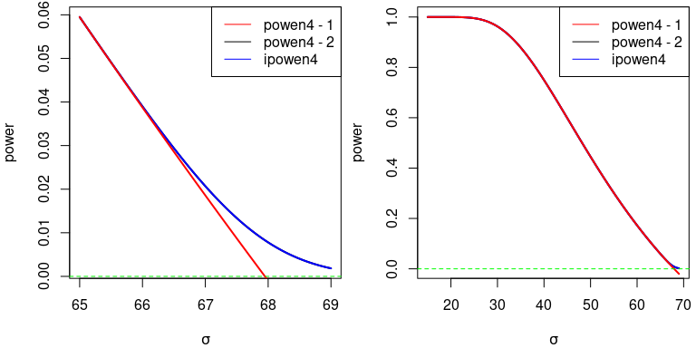

Note that the discrepancy between `powen4` and `ipowen4` occurs only for $\sigma > 65$.

- For $n_1=n_2=720$, $\alpha=0.05$, $\delta=0$, $\Delta=5$, we observe a discrepancy between `powen4` with the option `algo=1` and `ipowen4`:

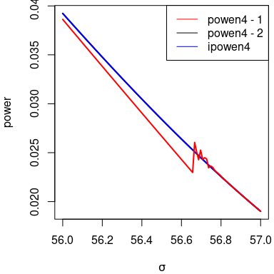

There is no discrepancy between `powen4` with the option `algo=2` and `ipowen4`. The irregularity of `powen4` with the option `algo=1` suggests that it returns wrong values.

[figure not shown]

With the option `algo=2`, the results of `powen4` coincide with the ones of `ipowen4`.

- For $n_1 = n_2 = 600$, $\alpha=0.005$, $\delta=0$, $\Delta=5$, we do not observe any discrepancy between `powen4` and `ipowen4`:

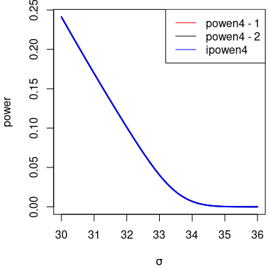

We conclude that `powen4` with the option `algo=1` is not reliable when the number of degrees of freedom is too large. As said before, the interest of the option `algo=1` is that the evaluation is faster.

For $n_1=n_2=2500$, the results of `powerTOST` with `algo=2` still coincide with the result of `ipowerTOST`:

```r
alpha <- 0.05; delta0 <- 0; Delta <- 5
sigma <- 110
n1 <- n2 <- 2500
powerTOST(alpha, delta0, Delta, sigma, n1, n2)
```

```
## [1] 4.523596e-05
```

```r
ipowerTOST(alpha, delta0, Delta, sigma, n1, n2)
```

```
## [1] 4.523596e-05
## attr(,"err_est")
## [1] 5.022201e-19
## attr(,"err_code")
## [1] 0
```

And even for $n_1=n_2=5000$:

```r
sigma <- 152
n1 <- n2 <- 5000
powerTOST(alpha, delta0, Delta, sigma, n1, n2)
```

```
## [1] 0.003612374
```

```r
ipowerTOST(alpha, delta0, Delta, sigma, n1, n2)
```

```
## [1] 0.003612374
## attr(,"err_est")
## [1] 4.010541e-17
## attr(,"err_code")
## [1] 0
```

### 4.2.2 Comparisons for $n_1+n_2 \leq 1200$

Below we compare the results returned by `powerTOST` to the ones returned by `ipowerTOST` for the parameters given in the `SAS` dataset.

```r
power <- ipower <- numeric(nrow(SAS))
for (i in 1:nrow(SAS)) {
  power[i] <-
    powerTOST(
      alpha = SAS$alpha[i],
      delta0 = SAS$delta0[i],
      Delta = SAS$Delta[i],
      sigma = SAS$sigma[i],
      n1 = SAS$n1[i],
      n2 = SAS$n2[i]
    )
  ipower[i] <-
    ipowerTOST(
      alpha = SAS$alpha[i],
      delta0 = SAS$delta0[i],
      Delta = SAS$Delta[i],
      sigma = SAS$sigma[i],
      n1 = SAS$n1[i],
      n2 = SAS$n2[i]
    )
}
identical(round(power, 10), round(ipower, 10))
```

```
## [1] TRUE
```

Results are the same up to $10$ digits. And also with the option `algo=1`:

```r
power <- numeric(nrow(SAS))
for (i in 1:nrow(SAS)) {
  power[i] <-
    powerTOST(
      alpha = SAS$alpha[i],
      delta0 = SAS$delta0[i],
      Delta = SAS$Delta[i],
      sigma = SAS$sigma[i],
      n1 = SAS$n1[i],
      n2 = SAS$n2[i],
      algo = 1
    )
}
identical(round(power, 10), round(ipower, 10))
```

```
## [1] TRUE
```

## 4.3 Conclusion

- The `powen4` function with option `algo=1` seems to return correct values for $\nu \leq 1200$.
- The `powen4` function with option `algo=2` allows higher values of $\nu$.
- In any case, we recommend to compare the result of `powen4` with the one of `ipowen4`.

# 5 Other Owen cumulative functions

We previously validated the `powen4` function for the $100$ scenarios of the dataset `SAS`.

Now we test the functions `powen1`, `powen2` and `powen3` by checking the equality
$$O_1(\nu, t_1, t_2, \delta_1, \delta_2) + O_2(\nu, t_1, t_2, \delta_1,
\delta_2)
+
O_3(\nu, t_1, t_2, \delta_1, \delta_2) + O_4(\nu, t_1, t_2, \delta_1,
\delta_2)
= 1.$$

We restrict our attention to default setting `algo=2`. We check the above equality for the $100$ scenarios of the dataset `SAS`.

```r
f <- function(alpha, delta0, Delta, sigma, n1, n2) {
  se <- sqrt(1/n1 + 1/n2) * sigma
  delta1 <- (delta0 + Delta) / se
  delta2 <- (delta0 - Delta) / se
  dof <- n1 + n2 - 2
  q <- qt(1 - alpha, dof)
  powen1(dof, q,-q, delta1, delta2) + powen2(dof, q,-q, delta1, delta2) +
    powen3(dof, q,-q, delta1, delta2) + powen4(dof, q,-q, delta1, delta2)
}
test <- numeric(nrow(SAS))
for (i in 1:nrow(SAS)) {
  test[i] <-
    f(
      alpha = SAS$alpha[i],
      delta0 = SAS$delta0[i],
      Delta = SAS$Delta[i],
      sigma = SAS$sigma[i],
      n1 = SAS$n1[i],
      n2 = SAS$n2[i]
    )
}
all(abs(test-1) < 1e-14)
```

```
## [1] TRUE
```

We find that each of the $100$ sums is equal to $1$ up to a tolerance of $14$ digits.

# 6 First Owen $Q$-function $Q_1$ (`OwenQ1`)

We previously validated the `powen4` function (implementation of the fourth Owen cumulative function $O_4$) for the $100$ scenarios of the dataset `SAS`.  
Now, to test `OwenQ1`, we will use the following equality:

$$O_4(\nu, t_1, t_2, \delta_1, \delta_2) =
Q_1\left(\nu, t_2, \delta_2,
\frac{\sqrt{\nu}(\delta_1-\delta_2)}{t_1-t_2}\right)
- Q_1\left(\nu, t_1, \delta_1,
\frac{\sqrt{\nu}(\delta_1-\delta_2)}{t_1-t_2}\right).$$

We use this formula to perform the power calculations with `OwenQ1` instead of `powen4`.

```r
powerTOST2 <- function(alpha, delta0, Delta, sigma, n1, n2) {
  se <- sqrt(1/n1 + 1/n2) * sigma
  delta1 <- (delta0 + Delta) / se
  delta2 <- (delta0 - Delta) / se
  dof <- n1 + n2 - 2
  q <- qt(1 - alpha, dof)
  R <- sqrt(dof)*(delta1 - delta2)/q/2
  OwenQ1(dof, -q, delta2, R) - OwenQ1(dof, q, delta1, R)
}
power2 <- numeric(nrow(SAS))
for (i in 1:nrow(SAS)) {
  power2[i] <-
    powerTOST2(
      alpha = SAS$alpha[i],
      delta0 = SAS$delta0[i],
      Delta = SAS$Delta[i],
      sigma = SAS$sigma[i],
      n1 = SAS$n1[i],
      n2 = SAS$n2[i]
    )
}
all(abs(power - power2) < 1e-9)
```

```
## [1] TRUE
```

The values rounded to $9$ digits are the same as the ones we previously obtained with `powen4`.

# 7 Second Owen $Q$-function $Q_2$ (`OwenQ2`)

We previously validated `powen2` for the $100$ scenarios of the dataset `SAS`. Now we test the `OwenQ2` function by checking the equality
$$O_2(\nu, t_1, t_2, \delta_1, \delta_2) =
Q_2\left(\nu, t_1, \delta_1,
\frac{\sqrt{\nu}(\delta_1-\delta_2)}{t_1-t_2}\right)
- Q_2\left(\nu, t_2, \delta_2,
\frac{\sqrt{\nu}(\delta_1-\delta_2)}{t_1-t_2}\right).$$

We check this equality for the $100$ scenarios of the dataset `SAS`.

```r
g <- function(alpha, delta0, Delta, sigma, n1, n2) {
  se <- sqrt(1/n1 + 1/n2) * sigma
  delta1 <- (delta0 + Delta) / se
  delta2 <- (delta0 - Delta) / se
  dof <- n1 + n2 - 2
  q <- qt(1 - alpha, dof)
  R <- sqrt(dof)*(delta1 - delta2)/q/2
  x <- OwenQ2(dof, q, delta1, R) - OwenQ2(dof, -q, delta2, R)
  y <- powen2(dof, q, -q, delta1, delta2)
  x - y
}
test <- numeric(nrow(SAS))
for (i in 1:nrow(SAS)) {
  test[i] <-
    g(
      alpha = SAS$alpha[i],
      delta0 = SAS$delta0[i],
      Delta = SAS$Delta[i],
      sigma = SAS$sigma[i],
      n1 = SAS$n1[i],
      n2 = SAS$n2[i]
    )
}
all(abs(test) < 1e-15)
```

```
## [1] TRUE
```

We find that each of the $100$ equalities hold true up to a tolerance of $15$ digits.

# 8 Student cumulative distribution function (`ptOwen`)

We finally test `ptOwen`, the implementation of the cumulative distribution function of the noncentral Student distribution.
If $T_1$ follows the noncentral Student distribution with number of degrees of freedom $\nu$ and noncentrality parameter $\delta_1$, then for any $t_1$ the equality
$$\Pr(T_1 \leq t_1) = O_1(\nu, t_1, t_2, \delta_1, \delta_2) + O_2(\nu,
t_1, t_2, \delta_1, \delta_2)$$
holds for any $t_2$ and $\delta_2$. We check this equality for the $100$ scenarios of the dataset `SAS`.

```r
h <- function(alpha, delta0, Delta, sigma, n1, n2) {
  se <- sqrt(1/n1 + 1/n2) * sigma
  delta1 <- (delta0 + Delta) / se
  delta2 <- (delta0 - Delta) / se
  dof <- n1 + n2 - 2
  q <- qt(1 - alpha, dof)
  x <- ptOwen(q, dof, delta1)
  y <- powen1(dof, q, -q, delta1, delta2) + powen2(dof, q, -q, delta1, delta2)
  x - y
}
test <- numeric(nrow(SAS))
for (i in 1:nrow(SAS)) {
  test[i] <-
    h(
      alpha = SAS$alpha[i],
      delta0 = SAS$delta0[i],
      Delta = SAS$Delta[i],
      sigma = SAS$sigma[i],
      n1 = SAS$n1[i],
      n2 = SAS$n2[i]
    )
}
all(abs(test) < 1e-15)
```

```
## [1] TRUE
```

For each scenario, the equality holds up to a tolerance of $15$ digits.

# 9 References

- Patefield, M. (2000). *Fast and Accurate Calculation of Owen’s T Function.* Journal of Statistical Software 5 (5), 1-25.
- Owen, D. B. (1965). *A special case of a bivariate noncentral t-distribution.* Biometrika 52, 437-446.
- Wolfram Alpha LLC. 2017. Wolfram|Alpha. (access July 17, 2017).